# Project1

Francis Espiritu

2025-02-28

## Introduction:

#### This data contains records of fitness-related data that analyzes the workout efficiency of the users based on many variables.

#### My motivation for this project is based on personal interest as one of my hobby is strength training and I’m in search of a workout that will increase my calorie burn.

#### Link: https://www.kaggle.com/datasets/adilshamim8/workout-and-fitness-tracker-data

```r
library(tidyverse)
```

```r
library(ggplot2)
library(dplyr)
library(hexbin)
```

```r
setwd("/Users/francisespiritu/COMP162")
fitness_tracker <- read_csv("workout_fitness_tracker_data.csv")
colnames(fitness_tracker)
```

```
##  [1] "User ID"                  "Age"
##  [3] "Gender"                   "Height (cm)"
##  [5] "Weight (kg)"              "Workout Type"
##  [7] "Workout Duration (mins)"  "Calories Burned"
##  [9] "Heart Rate (bpm)"         "Steps Taken"
## [11] "Distance (km)"            "Workout Intensity"
## [13] "Sleep Hours"              "Water Intake (liters)"
## [15] "Daily Calories Intake"    "Resting Heart Rate (bpm)"
## [17] "VO2 Max"                  "Body Fat (%)"
## [19] "Mood Before Workout"      "Mood After Workout"
```

```r
str(fitness_tracker)
```

```
## spc_tbl_ [10,000 × 20] (S3: spec_tbl_df/tbl_df/tbl/data.frame)
##  $ User ID                 : num [1:10000] 1 2 3 4 5 6 7 8 9 10 ...
##  $ Age                     : num [1:10000] 39 36 25 56 53 33 48 59 37 45 ...
##  $ Gender                  : chr [1:10000] "Male" "Other" "Female" "Male" ...
##  $ Height (cm)             : num [1:10000] 175 157 180 154 194 162 151 189 182 198 ...
##  $ Weight (kg)             : num [1:10000] 99 112 66 89 59 81 82 61 113 74 ...
##  $ Workout Type            : chr [1:10000] "Cycling" "Cardio" "HIIT" "Cycling" ...
##  $ Workout Duration (mins) : num [1:10000] 79 73 27 39 56 11 109 83 25 60 ...
##  $ Calories Burned         : num [1:10000] 384 612 540 672 410 301 351 518 226 265 ...
##  $ Heart Rate (bpm)        : num [1:10000] 112 168 133 118 170 142 114 159 123 171 ...
##  $ Steps Taken             : num [1:10000] 8850 2821 18898 14102 16518 ...
##  $ Distance (km)           : num [1:10000] 14.44 1.1 7.28 6.55 3.17 ...
##  $ Workout Intensity       : chr [1:10000] "High" "High" "High" "Medium" ...
##  $ Sleep Hours             : num [1:10000] 8.2 8.6 9.8 5.8 7.3 4.2 4.3 8.8 4.1 5.6 ...
##  $ Water Intake (liters)   : num [1:10000] 1.9 1.9 1.9 1.9 1.9 1.9 1.9 1.9 1.9 1.9 ...
##  $ Daily Calories Intake   : num [1:10000] 3195 2541 3362 2071 3298 ...
##  $ Resting Heart Rate (bpm): num [1:10000] 61 73 80 65 59 69 72 62 53 53 ...
##  $ VO2 Max                 : num [1:10000] 38.4 38.4 38.4 38.4 38.4 38.4 38.4 38.4 38.4 38.4 ...
##  $ Body Fat (%)            : num [1:10000] 28.5 28.5 28.5 28.5 28.5 28.5 28.5 28.5 28.5 28.5 ...
##  $ Mood Before Workout     : chr [1:10000] "Tired" "Happy" "Happy" "Neutral" ...
##  $ Mood After Workout      : chr [1:10000] "Fatigued" "Energized" "Fatigued" "Neutral" ...
##  - attr(*, "spec")=
##   .. cols(
##   ..   `User ID` = col_double(),
##   ..   Age = col_double(),
##   ..   Gender = col_character(),
##   ..   `Height (cm)` = col_double(),
##   ..   `Weight (kg)` = col_double(),
##   ..   `Workout Type` = col_character(),
##   ..   `Workout Duration (mins)` = col_double(),
##   ..   `Calories Burned` = col_double(),
##   ..   `Heart Rate (bpm)` = col_double(),
##   ..   `Steps Taken` = col_double(),
##   ..   `Distance (km)` = col_double(),
##   ..   `Workout Intensity` = col_character(),
##   ..   `Sleep Hours` = col_double(),
##   ..   `Water Intake (liters)` = col_double(),
##   ..   `Daily Calories Intake` = col_double(),
##   ..   `Resting Heart Rate (bpm)` = col_double(),
##   ..   `VO2 Max` = col_double(),
##   ..   `Body Fat (%)` = col_double(),
##   ..   `Mood Before Workout` = col_character(),
##   ..   `Mood After Workout` = col_character()
##   .. )
##  - attr(*, "problems")=<externalptr>
```

```r
summary(fitness_tracker)
```

```
##     User ID           Age           Gender           Height (cm)
##  Min.   :    1   Min.   :18.00   Length:10000       Min.   :150.0
##  1st Qu.: 2501   1st Qu.:28.00   Class :character   1st Qu.:162.0
##  Median : 5000   Median :38.00   Mode  :character   Median :174.0
##  Mean   : 5000   Mean   :38.39                      Mean   :174.3
##  3rd Qu.: 7500   3rd Qu.:49.00                      3rd Qu.:187.0
##  Max.   :10000   Max.   :59.00                      Max.   :199.0
##   Weight (kg)    Workout Type       Workout Duration (mins) Calories Burned
##  Min.   : 50.0   Length:10000       Min.   : 10.00          Min.   :100.0
##  1st Qu.: 67.0   Class :character   1st Qu.: 37.00          1st Qu.:325.0
##  Median : 85.0   Mode  :character   Median : 64.00          Median :554.0
##  Mean   : 84.9                      Mean   : 64.46          Mean   :552.1
##  3rd Qu.:102.0                      3rd Qu.: 92.00          3rd Qu.:776.0
##  Max.   :119.0                      Max.   :119.00          Max.   :999.0
##  Heart Rate (bpm)  Steps Taken    Distance (km)    Workout Intensity
##  Min.   : 80.0    Min.   : 1000   Min.   : 0.500   Length:10000
##  1st Qu.:105.0    1st Qu.: 5673   1st Qu.: 4.240   Class :character
##  Median :130.0    Median :10434   Median : 7.850   Mode  :character
##  Mean   :129.5    Mean   :10455   Mean   : 7.821
##  3rd Qu.:155.0    3rd Qu.:15211   3rd Qu.:11.410
##  Max.   :179.0    Max.   :19998   Max.   :15.000
##   Sleep Hours     Water Intake (liters) Daily Calories Intake
##  Min.   : 4.000   Min.   :1.9           Min.   :1500
##  1st Qu.: 5.500   1st Qu.:1.9           1st Qu.:2124
##  Median : 7.000   Median :1.9           Median :2753
##  Mean   : 6.983   Mean   :1.9           Mean   :2748
##  3rd Qu.: 8.400   3rd Qu.:1.9           3rd Qu.:3360
##  Max.   :10.000   Max.   :1.9           Max.   :3999
##  Resting Heart Rate (bpm)    VO2 Max      Body Fat (%)  Mood Before Workout
##  Min.   :50.00            Min.   :38.4   Min.   :28.5   Length:10000
##  1st Qu.:60.00            1st Qu.:38.4   1st Qu.:28.5   Class :character
##  Median :69.00            Median :38.4   Median :28.5   Mode  :character
##  Mean   :69.49            Mean   :38.4   Mean   :28.5
##  3rd Qu.:80.00            3rd Qu.:38.4   3rd Qu.:28.5
##  Max.   :89.00            Max.   :38.4   Max.   :28.5
##  Mood After Workout
##  Length:10000
##  Class :character
##  Mode  :character
##
##
##
```

## Visual Analysis: Hexbin

#### If we look at the HIIT graph, we can see that more users were able to loose about 900 calories in just 50 minutes. Compared to strength training, there is a less data input of users that lost the same about of calories within the same duration.

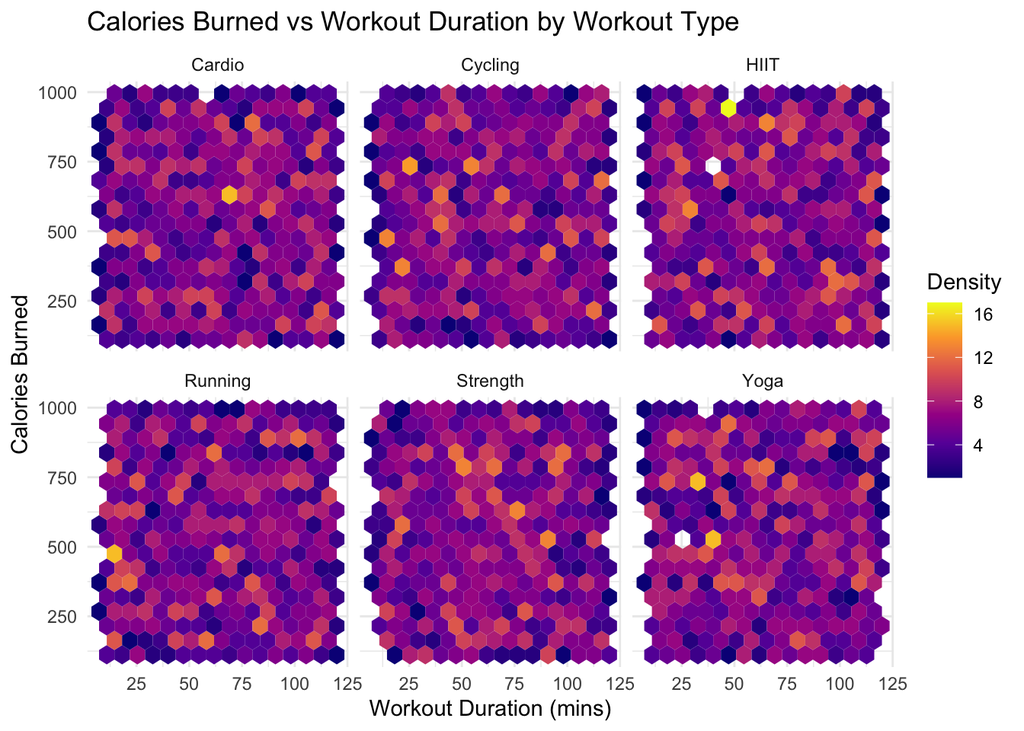

```r
ggplot(fitness_tracker, aes(x = `Workout Duration (mins)`, y = `Calories Burned`)) +
  geom_hex(bins = 15) +
  scale_fill_viridis_c(option = "C", name = "Density") +
  facet_wrap(~ `Workout Type`) +  # Separate hexbin plots for each workout type
  labs(title = "Calories Burned vs Workout Duration by Workout Type",
       x = "Workout Duration (mins)",
       y = "Calories Burned") +
  theme_minimal()
```

## Visual Analysis: Boxplot

#### This is a categorical vs quantitative plot. One observation I noticed is that this data set doesn’t have any outliers. Another is that the workout types have a similar median. It did surprise me that yoga is on the same average of calorie burn with all of these workouts because I didn’t know one can burn that much calorie with yoga workouts. But it probably also depend on the intensity.

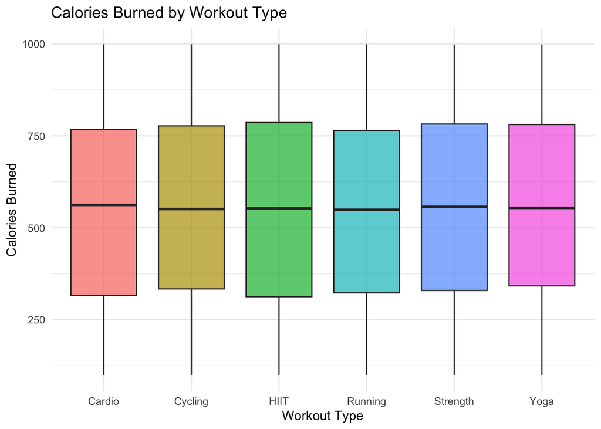

```r
ggplot(fitness_tracker, aes(x = `Workout Type`, y = `Calories Burned`, fill = `Workout Type`)) +
  geom_boxplot(alpha = 0.7) +
  labs(title = "Calories Burned by Workout Type",
       x = "Workout Type",
       y = "Calories Burned") +
  theme_minimal() +
  theme(legend.position = "none")
```

## Dataset Manipulation: dplyr

#### This dataset shows the average heart rate per workout duration with the use of dplyr manipulation. This is another interesting finding to me because Yoga actually generated the highest average heart rate especially compared to HIIT.

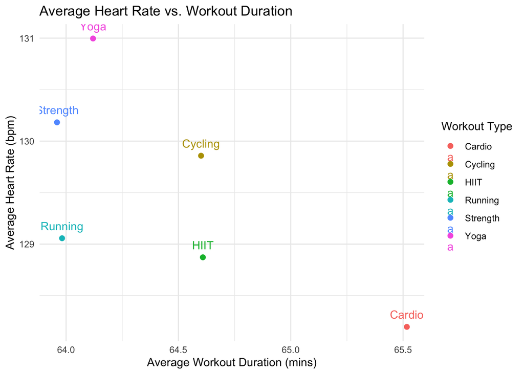

```r
# Data Manipulation: Calculate average heart rate per workout type
heart_rate_summary <- fitness_tracker %>%
  group_by(`Workout Type`) %>%
  summarize(avg_heart_rate = mean(`Heart Rate (bpm)`, na.rm = TRUE),
            avg_duration = mean(`Workout Duration (mins)`, na.rm = TRUE))

# Scatter plot: Average Heart Rate vs. Average Workout Duration
ggplot(heart_rate_summary, aes(x = avg_duration, y = avg_heart_rate, color = `Workout Type`)) +
  geom_point(size = 2) +
  geom_text(aes(label = `Workout Type`), vjust = -1) + # Add labels for readability
  labs(title = "Average Heart Rate vs. Workout Duration",
       x = "Average Workout Duration (mins)",
       y = "Average Heart Rate (bpm)") +
  theme_minimal()
```

## Statistical Analysis: Two Quantitative Variables

### Pearson

#### Null Hypothesis: There is no correlation between Heart Rate and Calories Burned.

#### Alternative Hypothesis: There is a correlation between Heart Rate and Calories Burned.

```r
# Perform Pearson correlation test
pearson_bpm_cals <- cor.test(fitness_tracker$`Heart Rate (bpm)`,
                             fitness_tracker$`Calories Burned`,
                             method = "pearson",
                             use = "complete.obs")

# Print the full result
print(pearson_bpm_cals)
```

```
##
##  Pearson's product-moment correlation
##
## data:  fitness_tracker$`Heart Rate (bpm)` and fitness_tracker$`Calories Burned`
## t = -0.65934, df = 9998, p-value = 0.5097
## alternative hypothesis: true correlation is not equal to 0
## 95 percent confidence interval:
##  -0.02619061  0.01300783
## sample estimates:
##          cor
## -0.006593923
```

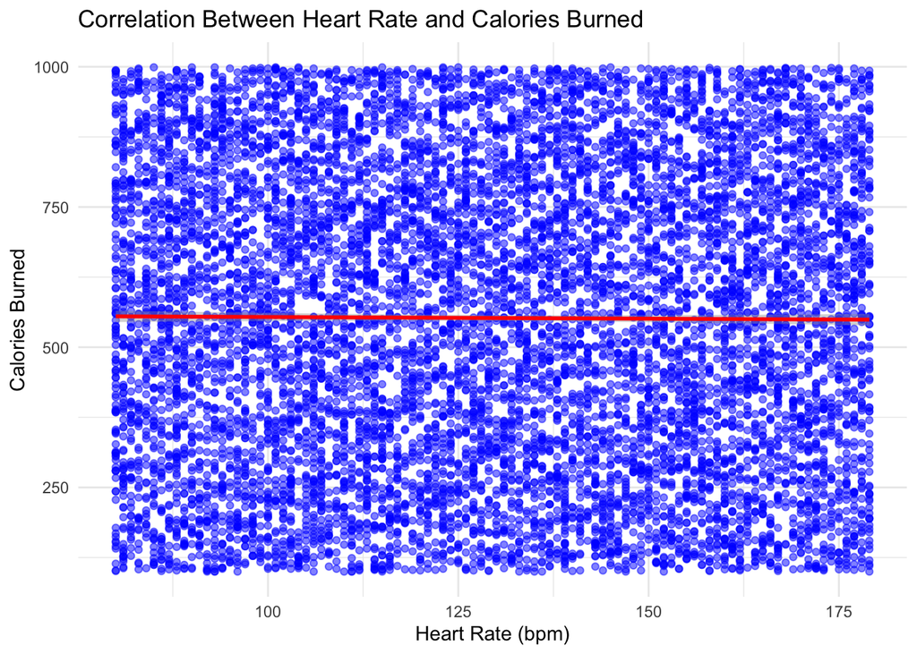

```r
ggplot(fitness_tracker, aes(x = `Heart Rate (bpm)`, y = `Calories Burned`)) +
  geom_point(alpha = 0.5, color = "blue") +  # Scatter plot with transparency
  geom_smooth(method = "lm", color = "red", se = TRUE) +  # Linear regression line
  labs(title = "Correlation Between Heart Rate and Calories Burned",
       x = "Heart Rate (bpm)",
       y = "Calories Burned") +
  theme_minimal()
```

#### Based on this Pearson Correlation Test, we failed to reject the null hypothesis since the p-value is greater than 0.05.Therefore, there is no statistically significant correlation between Heart Rate and Calories Burned.

#### The t-value suggests that we have a weak evidence of correlation.

#### Coefficient correlation is close to 0, meaning that there’s no significant relationship between the two variables.

### Linear Regression

```r
# Run a linear regression model
lm_bpm_cals <- lm(`Calories Burned` ~ `Heart Rate (bpm)`, data = fitness_tracker)

# Print the summary of the model
summary(lm_bpm_cals)
```

```
##
## Call:
## lm(formula = `Calories Burned` ~ `Heart Rate (bpm)`, data = fitness_tracker)
##
## Residuals:
##     Min      1Q  Median      3Q     Max
## -454.33 -226.59    1.87  224.39  448.55
##
## Coefficients:
##                     Estimate Std. Error t value Pr(>|t|)
## (Intercept)        559.81016   11.97950  46.731   <2e-16 ***
## `Heart Rate (bpm)`  -0.05952    0.09027  -0.659     0.51
## ---
## Signif. codes:  0 '***' 0.001 '**' 0.01 '*' 0.05 '.' 0.1 ' ' 1
##
## Residual standard error: 260.6 on 9998 degrees of freedom
## Multiple R-squared:  4.348e-05,  Adjusted R-squared:  -5.654e-05
## F-statistic: 0.4347 on 1 and 9998 DF,  p-value: 0.5097
```

#### Just like the pearson test, the linear regression are very weak suggesting that there is no correlation between Heart Rate and Calories Burned. The R squared is very close to 0 and the p-value fails to reject the null hypothesis again.

## T-test: Categorical vs. Quantitative

#### Null Hypothesis: There is no significant correlation between male and female calorie burn in high-intensity strength workouts.

#### Alternate Hypothesis: There is a significant correlation between male and female calorie burn in high-intensity strength workouts.

```r
# Subset data for high-intensity strength workouts
high_intensity_strength <- subset(fitness_tracker,
                                  `Workout Type` == "Strength" &
                                    `Workout Intensity` == "High" &
                                    Gender %in% c("Male", "Female"))

# Perform Welch's t-test
t_test_result <- t.test(`Calories Burned` ~ Gender,
                        data = high_intensity_strength,
                        var.equal = FALSE)

# Print result
print(t_test_result)
```

```
##
##  Welch Two Sample t-test
##
## data:  Calories Burned by Gender
## t = -2.1974, df = 373.36, p-value = 0.0286
## alternative hypothesis: true difference in means between group Female and group Male is not equal to 0
## 95 percent confidence interval:
##  -104.772111   -5.815183
## sample estimates:
## mean in group Female   mean in group Male
##             522.9423             578.2360
```

#### We were able to reject the null hypothesis since the p-value is lower than 0.05, suggesting that there is a significant correlation between make and female calorie burn in high-intensity strength workouts.

#### The t value indicates that on average, women burn fewer calories than men during high-intensity workouts. We can also see the 55cal difference.

## Presentation Analysis

```r
# Perform linear regression
linear_model <- lm(`Calories Burned` ~ `Gender`, data = high_intensity_strength)

# Print model summary
summary(linear_model)
```

```
##
## Call:
## lm(formula = `Calories Burned` ~ Gender, data = high_intensity_strength)
##
## Residuals:
##     Min      1Q  Median      3Q     Max
## -476.24 -198.69    5.26  213.76  472.06
##
## Coefficients:
##             Estimate Std. Error t value Pr(>|t|)
## (Intercept)   522.94      17.07   30.63   <2e-16 ***
## GenderMale     55.29      25.14    2.20   0.0284 *
## ---
## Signif. codes:  0 '***' 0.001 '**' 0.01 '*' 0.05 '.' 0.1 ' ' 1
##
## Residual standard error: 246.2 on 384 degrees of freedom
## Multiple R-squared:  0.01244,    Adjusted R-squared:  0.009871
## F-statistic: 4.838 on 1 and 384 DF,  p-value: 0.02843
```

```r
# Run Linear Regression
model <- lm(`Calories Burned` ~ Gender + `Workout Duration (mins)`, data = high_intensity_strength)

# Summary of the regression
summary(model)
```

```
##
## Call:
## lm(formula = `Calories Burned` ~ Gender + `Workout Duration (mins)`,
##     data = high_intensity_strength)
##
## Residuals:
##     Min      1Q  Median      3Q     Max
## -484.02 -200.20    5.54  214.78  471.60
##
## Coefficients:
##                           Estimate Std. Error t value Pr(>|t|)
## (Intercept)               504.8622    31.8900  15.831   <2e-16 ***
## GenderMale                 55.1699    25.1569   2.193   0.0289 *
## `Workout Duration (mins)`   0.2825     0.4208   0.671   0.5024
## ---
## Signif. codes:  0 '***' 0.001 '**' 0.01 '*' 0.05 '.' 0.1 ' ' 1
##
## Residual standard error: 246.4 on 383 degrees of freedom
## Multiple R-squared:  0.0136, Adjusted R-squared:  0.008453
## F-statistic: 2.641 on 2 and 383 DF,  p-value: 0.07259
```

```r
calories_summary <- fitness_tracker %>%
  group_by(`Workout Type`) %>%
  summarize(avg_calories = mean(`Calories Burned`, na.rm = TRUE)) %>%
  arrange(desc(avg_calories))
```